# Análisis Multivariado - Clase 2

## Vectores

## Definiciones

Un vector se puede definir como un segmento orientado. Las características principales son las siguientes:

- **Módulo:** La longitud del segmento.
- **Dirección:** La recta sobre la que se ubica el segmento
- **Sentido:** Uno de los puntos se considera de partida y el otro de llegada.

## Espacios vectoriales

- En un espacio vectorial, se agrega una noción de origen. Se considera que todos los vectores parten del origen y llega hacia el punto deseado.
- Por eso, los componentes del vector se llaman “coordenadas”. Porque la idea es partir del origen y “ubicar” el punto deseado.
- Si bien hay muchas generalizaciones a los espacios vectoriales, cuando un vector \(\vec{v}\) tiene \(n\) coordenadas y las mismas son números reales, se dice que \(\vec{v} \in \mathbb{R}^n\).

## Ejemplos:

- \(\vec{u_2}=(3,4) \in \mathbb{R}^2\)
- \(\vec{v_2}=(-2,5)\in \mathbb{R}^2\)
- \(\vec{u_3}= (1,2,-1)\in \mathbb{R}^3\)
- \(\vec{v_3}= (2,0,1)\in \mathbb{R}^3\)
- \(\vec{w_3}= (-1,3,1)\in \mathbb{R}^3\)

## Ejemplos gráficos (\(\mathbb{R}^2\))

- \(\vec{u_2}=(3,4) \in \mathbb{R}^2\)
- \(\vec{v_2}=(-2,5)\in \mathbb{R}^2\)

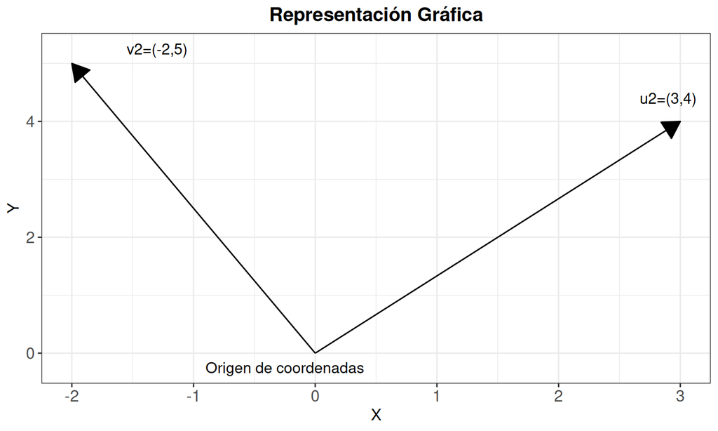

## Ejemplos gráficos (\(\mathbb{R}^3\))

\(\vec{u_3}= (1,2,-1)\in \mathbb{R}^3 \quad \vec{v_3}= (2,0,1)\in \mathbb{R}^3\quad \vec{w_3}= (-1,3,1)\in \mathbb{R}^3\)

[interactive chart not shown]

## Vector entre dos puntos

Es también por este motivo, es que el vector entre dos puntos \(\vec{u}\) y \(\vec{v}\) se suele escribir como \(\vec{v}-\vec{u}\). Porque es un vector con el mismo módulo, una dirección paralela y el mismo sentido.

**Ejemplos:**

- \(\vec{v_2}-\vec{u_2}=(-2,5)-(3,4)=(-5,1)\)

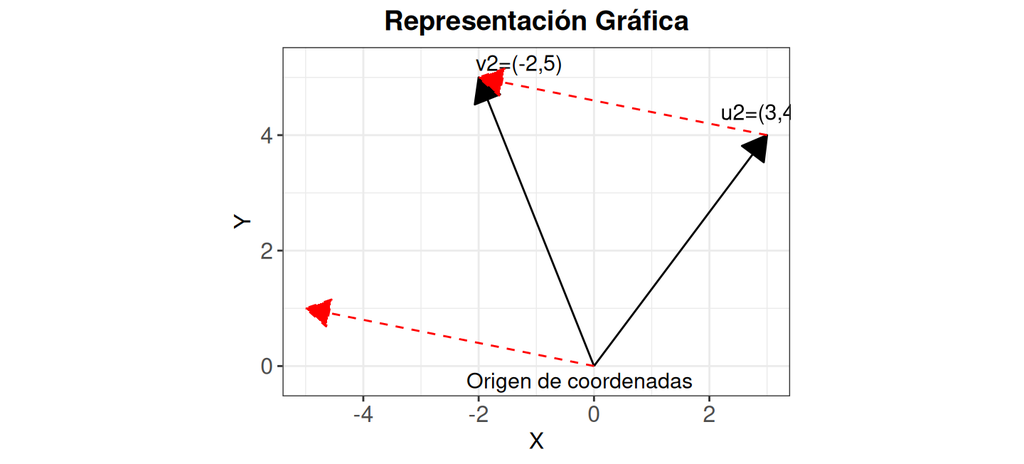

## Normas

Las normas son funciones que asignan un número positivo a cada vector según su distancia al origen.

**Ejemplos:**

- **Norma 2:** \(||\vec{v}||_2=\sqrt{\sum_{i=1}^n v_i^2}\)
  - \(||\vec{u_2}||_2=||(3,4)||_2=\sqrt{3^2+4^2}=5\)
  - \(||\vec{v_2}||_2=||-2,5||_2=\sqrt{(-2)^2+5^2}=\sqrt{29}\)
- **Norma 1:** \(||\vec{v}||_1=\sum_{i=1}^n |v_i|\)
  - \(||\vec{u_2}||_1=||(3,4)||_1=|3|+|4|=7\)
  - \(||\vec{v_2}||_1=||-2,5||_1=|-2|+|5|=7\)

## Normas

Las normas son funciones que asignan un número positivo a cada vector según su distancia al origen.

- **Norma \(p\):** \(||\vec{v}||_p=\left(\sum_{i=1}^n |v_i|^p\right)^{\frac{1}{p}}\) (\(p>0\))
  - \(||\vec{u_2}||_3=||(3,4)||_3=\sqrt[3]{|3|^3+|4|^3}=\sqrt[3]{91}\)
  - \(||\vec{v_2}||_{\frac{1}{2}}=||(-2,5)||_{\frac{1}{2}} =\left(|-2|^{\frac{1}{2}}+|5|^{\frac{1}{2}}\right)^2=\\=(\sqrt{2}+\sqrt{5})^2=7+2\cdot \sqrt{10}\)

## Múltiplos de vectores

Multiplicar un vector por una constante \(k\), mantiene la dirección del vector, pero cambia su longitud y (en caso de ser \(k\) negativa) puede cambiar su sentido:

**Ejemplos:**

- \(2\cdot \vec{u_2} =2\cdot (3,4) =(6,8)\)
- \((-3)\cdot \vec{v_2}= (-3)\cdot (-2,5)=(6,-15)\)

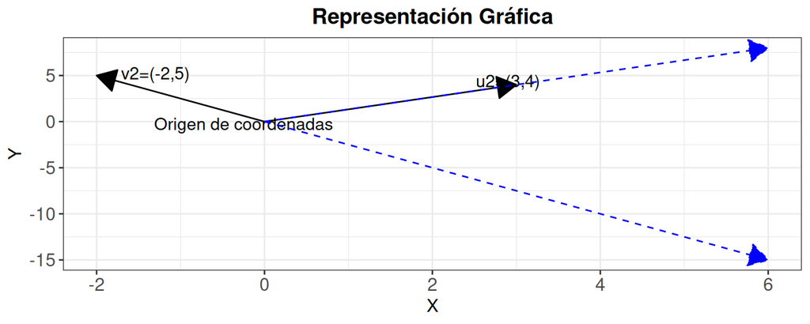

## Distancias entre vectores

La mayoría de las distancias entre vectores utilizadas se basan en normas. La idea es que si dos vectores están más (o menos) alejados entre sí, su resta estará más (o menos) alejado del origen.

- **Distancia euclídea:** \(d_E(\vec{u},\vec{v})=||\vec{v}-\vec{u}||_2\)
  - **Ejemplo:** \(d_E(\vec{u_2},\vec{v_2})=||\vec{v_2}-\vec{u_2}||_2=||(-5,1)||_2= \\=\sqrt{(-5)^2+1^2}=\sqrt{26}\)
- Distancia Manhattan: \(d_M(\vec{u},\vec{v})=||\vec{v}-\vec{u}||_1\)
  - **Ejemplo:** \(d_M(\vec{u_2},\vec{v_2})=||\vec{v_2}-\vec{u_2}||_1=||(-5,1)||_1=\\=|-5|+|1|=6\)

## Distancias entre vectores

La mayoría de las distancias entre vectores utilizadas se basan en normas. La idea es que si dos vectores están más (o menos) alejados entre sí, su resta estará más (o menos) alejado del origen.

- Distancia Minkowski: \(d_{p}(\vec{u},\vec{v})=||\vec{v}-\vec{u}||_p\)
  - **Ejemplo:** \(d_4(\vec{u_2},\vec{v_2})=||\vec{v_2}-\vec{u_2}||_4=||(-5,1)||_4=\\=\sqrt[4]{(-5)^4+1^4}=\sqrt[4]{626}\)

## Producto interno

Una forma de multiplicar vectores es con lo que se denomina “producto escalar” o “producto interno”:

- Producto escalar: \(\vec{u}\cdot\vec{v}=\sum_{i=1}^n u_i\cdot v_i\)
  - **Ejemplo:** \(\vec{u_2}\cdot \vec{v_2}=(3,4)\cdot (-2,5)=3\cdot (-2)+4\cdot 5=14\)

El producto interno de dos vectores se vincula con el ángulo entre los mismos:

\(\vec{u}\cdot\vec{v}=||\vec{u}||_2 \cdot ||\vec{v}||_2\cdot \cos (\widehat{\alpha})\)

donde \(\widehat{\alpha}\) representa el ángulo entre dos vectores. Por lo tanto,

\(\cos (\widehat{\alpha}) =\dfrac{\vec{u}\cdot\vec{v}}{||\vec{u}||_2 \cdot ||\vec{v}||_2}\)

## Ejemplo

\(\small \cos (\widehat{\alpha}(\vec{u}_2,\vec{v}_2)) =\dfrac{\vec{u}_2\cdot\vec{v}_2}{||\vec{u}_2||_2 \cdot ||\vec{v}_2||_2}=\dfrac{(3,4)\cdot (-2,5)}{||(3,4)||_2 \cdot ||(-2,5)||_2}=\dfrac{14}{5\cdot \sqrt{29}}\Rightarrow\)

\(\small \Rightarrow\widehat{\alpha}(\vec{u}_2,\vec{v}_2) \approx 58.67131\)

**Notas:**

- Si \(\vec{u}\perp \vec{v}\Rightarrow \widehat{\alpha}=90º \Rightarrow \vec{u}\cdot \vec{v}=0\).
- Por otro lado, \(\vec{u}\cdot \vec{u}=||\vec{u}||_2^2\) ya que el ángulo entre vectores de la misma dirección es \(\alpha=0\Rightarrow \cos(\alpha)=1\)

## Proyección entre vectores

Cuando se intenta proyectar un vector \(\vec{u}\) sobre otro vector \(\vec{v}\), se intenta buscar un múltiplo de \(\vec{v}\) más cercano a \(\vec{u}\).

Gráficamente, se ve que el múltiplo de \(\vec{v}\) más cercano a \(\vec{u}\), se obtiene generando un triángulo rectángulo con una proyección ortogonal.

La **longitud** de dicho vector de proyección debería ser la siguiente:

\(\scriptsize ||\vec{u}||_2\cdot \cos(\widehat{\alpha})= ||\vec{u}||_2\cdot \dfrac{\vec{u}\cdot \vec{v}}{||\vec{u}||_2\cdot ||\vec{v}||_2}= \dfrac{\vec{u}\cdot \vec{v}}{ ||\vec{v}||_2}\)

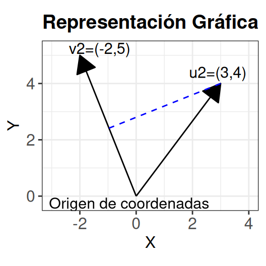

## Proyección entre vectores

Por lo tanto, se considera multiplicar por un vector en la misma dirección de \(\vec{v}\), pero de longitud 1. Un vector que cumple dicha condición es el vector normalizado \(\frac{\vec{v}}{||\vec{v}||_2}\). Si multiplicamos este vector normalizado por la longitud deseada, obtenemos el vector de proyección: \(\scriptsize \begin{vmatrix}\begin{vmatrix}\dfrac{\vec{u}\cdot \vec{v}}{ ||\vec{v}||_2}\cdot \dfrac{\vec{v}}{||\vec{v}||_2}\end{vmatrix}\end{vmatrix}_2=\dfrac{|\vec{u}\cdot \vec{v}|\cdot ||\vec{v}||_2}{||\vec{v}||_2^2}= \dfrac{|\vec{u}\cdot \vec{v}|}{||\vec{v}||_2}\Rightarrow \text{proy}_{\vec{v}}(\vec{u})=\dfrac{\vec{u}\cdot \vec{v}}{ ||\vec{v}||_2^2}\cdot \vec{v}\)

**Ejemplo:** \(\tiny \text{proy}_{\vec{v_2}}(\vec{u_2})=\dfrac{\vec{u_2}\cdot \vec{v_2}}{ ||\vec{v_2}||_2^2}\cdot \vec{v_2}=\dfrac{14}{29}\cdot (-2,5)=\left(-\dfrac{28}{29};\dfrac{70}{29} \right)\)

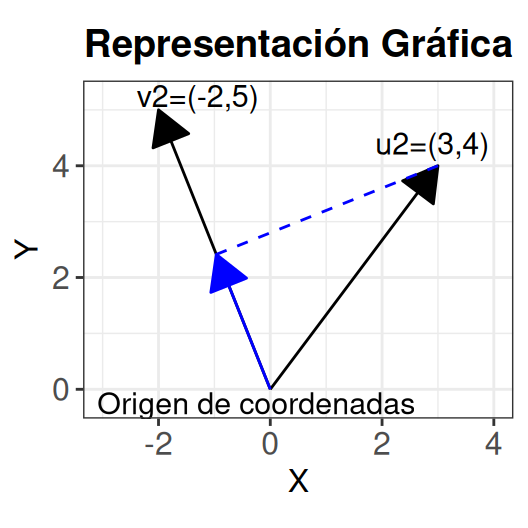

## Proyección entre vectores

Por lo tanto, si quisiéramos obtener la proyección de \(\vec{v}\) sobre \(\vec{u}\), se multiplica la longitud deseada\(\tiny \left(\frac{\vec{u}\cdot \vec{v}}{ ||\vec{u}||_2}\right)\) por el vector normalizado\(\tiny \left(\frac{\vec{u}}{||\vec{u}||_2}\right)\): \(\scriptsize \begin{vmatrix}\begin{vmatrix}\dfrac{\vec{u}\cdot \vec{v}}{ ||\vec{u}||_2}\cdot \dfrac{\vec{u}}{||\vec{u}||_2}\end{vmatrix}\end{vmatrix}_2=\dfrac{|\vec{u}\cdot \vec{v}|\cdot ||\vec{u}||_2}{||\vec{u}||_2^2}= \dfrac{|\vec{u}\cdot \vec{v}|}{||\vec{u}||_2}\Rightarrow \text{proy}_{\vec{v}}(\vec{u})=\dfrac{\vec{u}\cdot \vec{v}}{ ||\vec{u}||_2^2}\cdot \vec{u}\)

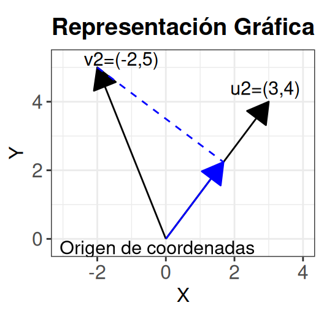

## Proyección ortogonal sobre un subespacio

Cuando se intenta proyectar un vector \(\vec{u}\) sobre un subespacio \(\mathbb{S}\) generado por vectores \(\vec{v}_1,\vec{v}_2,\cdots,\vec{v}_k\), se pueden sumar las proyecciones de \(\vec{u}\) sobre cada vector \(\vec{v}_1,\vec{v}_2,\cdots,\vec{v}_k\). Es decir,

\(\text{proy}_{\mathbb{S}}(\vec{u})= \text{proy}_{\vec{v_1}}(\vec{u})+\text{proy}_{\vec{v_2}}(\vec{u})+\cdots +\text{proy}_{\vec{v_k}}(\vec{u})\)

**Ejemplo:**

[interactive chart not shown]

## Matrices

## Definiciones

Una matriz \(A\) se puede ver como una tabla de coordenadas numéricas con \(n\) filas y \(m\) columnas. Se dice en este caso que \(A\in\mathbb{R}^{n\times m}\).

**Ejemplos:**

- \(\small A=\begin{pmatrix} 2& -1 &1\\-2&-1&1 \end{pmatrix}\in\mathbb{R}^{2\times 3}\)
- \(\small B=\begin{pmatrix} 2& -2 \\-1&-1 \\1&1 \end{pmatrix}\in\mathbb{R}^{3\times 2}\)
- \(\small C=\begin{pmatrix} 6& -2 \\-2&6 \end{pmatrix}\in\mathbb{R}^{2\times 2}\)
- \(\small D=\begin{pmatrix} 13&6& 3 \\6&10&6\\3&6&13 \end{pmatrix}\in\mathbb{R}^{3\times 3}\)

## Multiplicación de Matrices

La multiplicación entre matrices se realiza aplicando el producto interno a las filas de la matriz de la izquierda con las columnas de la matriz de la derecha.

**Ejemplos:**

\(\small A \times B=\underset{2\times 3}{\underbrace{ \begin{pmatrix} 2& -1 &1\\-2&-1&1 \end{pmatrix} }} \times \underset{3\times 2}{\underbrace{\begin{pmatrix} 2& -2 \\-1&-1 \\1&1 \end{pmatrix}}}=\)

\(\small =\begin{pmatrix} 2\cdot 2 + (-1)\cdot (-1) + 1\cdot 1 & 2\cdot (-2) + (-1)\cdot (-1) + 1\cdot 1\\ (-2)\cdot 2 + (-1)\cdot (-1) + 1\cdot 1 & (-2)\cdot (-2) + (-1)\cdot (-1) + 1\cdot 1 \end{pmatrix}=\)

\(\small =\underset{2\times 2}{\underbrace{\begin{pmatrix} 6&-2\\-2&6 \end{pmatrix}}}\)

## Multiplicación de Matrices

La multiplicación entre matrices se realiza aplicando el producto interno a las filas de la matriz de la izquierda con las columnas de la matriz de la derecha.

**Ejemplos:**

- \(\scriptsize B\times A=\underset{3\times 2}{\underbrace{\begin{pmatrix} 2& -2 \\-1&-1 \\1&1 \end{pmatrix} }}\times \underset{2\times 3}{\underbrace{\begin{pmatrix} 2& -1 &1\\-2&-1&1 \end{pmatrix}}} = \\ \scriptsize \begin{pmatrix} 2\cdot 2 + (-2)\cdot (-2) & 2\cdot (-1) + (-2)\cdot (-1) & 2\cdot 1 + (-2)\cdot 1\\ (-1)\cdot 2 + (-1)\cdot (-2) & (-1)\cdot (-1) + (-1)\cdot (-1) & (-1)\cdot 1 + (-1)\cdot 1\\ 1\cdot 2 + 1\cdot (-2) & 1\cdot (-1) + 1\cdot (-1) & 1\cdot 1 + 1\cdot 1 \end{pmatrix} = \\ \scriptsize \underset{3\times 3}{\underbrace{ \begin{pmatrix} 8 &0 &0\\0 & 2 &-2\\ 0 &-2&2 \end{pmatrix}}}\)

## Propiedades de la multiplicación

- **NO TODAS LAS MATRICES SE PUEDEN MULTIPLICAR:** Si se quiere realizar \(A\times B\), deben coincidir las columnas de \(A\) con las filas de \(B\). El resultado tiene la cantidad de filas de \(A\) y la cantidad de columnas de \(B\).
  - **Ejemplo:** Sean \(A=\begin{pmatrix} 2& -1 &1\\-2&-1&1 \end{pmatrix}\in\mathbb{R}^{2\times 3}\), \(C=\begin{pmatrix} 6& -2 \\-2&6 \end{pmatrix}\in\mathbb{R}^{2\times 2}\). Se puede realizar \(C\times A\). No se puede realizar \(A\times C\)
- La multiplicación entre matrices **NO ES CONMUTATIVA**. Es decir, no es lo mismo \(A\times B\) que \(B\times A\).

## Propiedades de la multiplicación

- Multiplicar una constante \(k\) por una matriz \(A\) resulta en multiplicar cada coordenada por la constante.
  - **Ejemplo:** Sea \(\scriptsize C=\begin{pmatrix} 6& -2 \\-2&6 \end{pmatrix}\in\mathbb{R}^{2\times 2}\Rightarrow 2\times C = \begin{pmatrix} 12& -4 \\-4&12 \end{pmatrix}\)
- Un vector \(\vec{v}\) puede verse como una matriz de una fila o de una columna y por lo tanto, si corresponden las dimensiones, se pueden multiplicar un vector y una matriz.
  - **Ejemplo:** Sea \(\scriptsize C=\begin{pmatrix}6&-2\\-2&6\end{pmatrix} \in\mathbb{R}^{2\times 2},\; \vec{u}_2=(3,4)\)

  \(\scriptsize \Rightarrow C \times \vec{u}_2 = \begin{pmatrix} 6& -2 \\-2&6 \end{pmatrix} \times \begin{pmatrix} 3 \\ 4 \end{pmatrix} = \begin{pmatrix} 10 \\ 18 \end{pmatrix},\\\scriptsize \vec{u}_2 \times C = \begin{pmatrix} 3 & 4 \end{pmatrix}\times \begin{pmatrix} 6& -2 \\-2&6 \end{pmatrix} = \begin{pmatrix} 10 & 18 \end{pmatrix}\)
- Se dice que una matriz es **cuadrada** si coinciden sus filas y columnas.

## Identidad

Se denomina la matriz Identidad \(I_n\) a aquella matriz **cuadrada** que tiene unos en la diagonal y ceros en el resto:

- **Ejemplos:** \(I_2=\begin{pmatrix} 1& 0 \\0&1 \end{pmatrix},\; I_3=\begin{pmatrix} 1& 0 &0 \\0&1 &0\\ 0&0&1 \end{pmatrix}\)

## Identidad

La matriz Identidad tiene la propiedad que si corresponde multiplicarla por una matriz \(A\), su multiplicación vuelve a dar la matriz \(A\):

- **Ejemplos:** \(A=\begin{pmatrix} 2& -1 &1\\-2&-1&1 \end{pmatrix} \Rightarrow\\ \Rightarrow A\times I_3= \begin{pmatrix} 2& -1 &1\\-2&-1&1 \end{pmatrix} \times \begin{pmatrix} 1& 0 &0 \\0&1 &0\\ 0&0&1 \end{pmatrix} =A,\;\\ I_2\times A=\begin{pmatrix} 1& 0 \\0&1 \end{pmatrix}\times \begin{pmatrix} 2& -1 &1\\-2&-1&1 \end{pmatrix}=A\)

## Determinante

El determinante es un número que se asocia a matrices **cuadradas** de forma recursiva. Se nota como det(\(A\)) o poniendo la matriz entre barras.

**Ejemplo:**

- \(\small n=1: A=\begin{pmatrix}13\end{pmatrix}\Rightarrow \text{det}=\begin{vmatrix}13\end{vmatrix}=13\)
- \(\small n=2: A=\begin{pmatrix}13&6\\6&10\end{pmatrix}\Rightarrow \text{det}=13\cdot\begin{vmatrix}10\end{vmatrix}-6\cdot \begin{vmatrix}6\end{vmatrix}=130-36=94\)
- \(\small n=3: A=\begin{pmatrix}13&6&3\\6&10&6\\3&6&13\end{pmatrix}\Rightarrow \\ \small \text{det}(A)=13\cdot\begin{vmatrix}10&6\\6&13\end{vmatrix}-6\cdot \begin{vmatrix}6&6\\3&13\end{vmatrix} + 3\cdot \begin{vmatrix}6&10\\3&6\end{vmatrix} =\\ \small 13\cdot (10\cdot 13- 6\cdot 6)-6\cdot (6\cdot 13- 3\cdot 6)+3\cdot (6\cdot 6- 3\cdot 10) =\\ \small = 13\cdot 94 - 6\cdot 60 + 3\cdot 6=1222-360+18=880\)

## Inversa

Dada una matriz **cuadrada** \(A\), si su determinante es distinto de cero, existe una **inversa** de \(A\) a una matriz \(A^{-1}\) que cumple: \(A\times A^{-1}=A^{-1}\times A=I_n\)

- \(\small C=\begin{pmatrix} 6& -2 \\-2&6 \end{pmatrix}\Rightarrow C^{-1}= \begin{pmatrix} \frac{3}{16}& \frac{1}{16} \\\frac{1}{16}&\frac{3}{16} \end{pmatrix}\), ya que \(\small \begin{pmatrix} 6& -2 \\-2&6 \end{pmatrix}\times \begin{pmatrix} \frac{3}{16}& \frac{1}{16} \\\frac{1}{16}&\frac{3}{16} \end{pmatrix}=\begin{pmatrix} \frac{3}{16}& \frac{1}{16} \\\frac{1}{16}&\frac{3}{16} \end{pmatrix}\times\begin{pmatrix} 6& -2 \\-2&6 \end{pmatrix}=\\ \small =\begin{pmatrix} 1& 0 \\0&1 \end{pmatrix}\)

## Inversa

Su cálculo se realiza resolviendo un sistema de ecuaciones igualando la matriz a la identidad, y despejando hasta lograr el orden inverso: \[\begin{pmatrix} 6& -2 &|&1 &0 \\-2&6&|&0 &1 \end{pmatrix}\overset{3F_2+F1}{\to} \begin{pmatrix} 6& -2 &|&1 &0 \\0&16&|&1 &3 \end{pmatrix} \]

\[\overset{8F_1+F2}{\to} \begin{pmatrix} 48& 0 &|&9 &3 \\0&16&|&1 &3 \end{pmatrix}\overset{F_1/48;F2/16}{\to} \begin{pmatrix} 1& 0 &|&\frac{3}{16} &\frac{1}{16} \\0&1&|&\frac{1}{16} &\frac{3}{16} \end{pmatrix} \]

## Transpuesta y Simetría

Dada una matriz \(A\) se denomina su transpuesta \(A^T\) a la matriz que invierte sus filas por sus columnas. Es decir, la primer fila de \(A\) es la primer columna de \(A^T\), la segunda fila de \(A\) es la segunda columna de \(A^T\).

- **Ejemplo:** \(A=\begin{pmatrix} 2& -1 &1\\-2&-1&1 \end{pmatrix}\in\mathbb{R}^{2\times 3}\Rightarrow A^T=\begin{pmatrix} 2& -2 \\-1&-1 \\1&1 \end{pmatrix}\in\mathbb{R}^{3\times 2}\)

Se dice que una matriz **cuadrada** es simétrica si \(A=A^T\).

- **Ejemplo:** \(C=\begin{pmatrix} 6& -2 \\-2&6 \end{pmatrix}=C^T,\;D=\begin{pmatrix} 13&6& 3 \\6&10&6\\3&6&13 \end{pmatrix}=D^T\)

## Autovalores y autovectores

Dada \(A\) una matriz **cuadrada**, se dice que un vector \(\vec{v}\neq \vec{0}\) es un autovector con autovalor asociado \(\lambda\) si se cumple: \[A\cdot \vec{v}=\lambda \vec{v}\] Es decir, luego de multiplicar la matriz por el vector, se obtiene un vector de la misma dirección.

## **Ejemplo:**

\(\vec{u}_2=(3,4)\) NO es autovector de \(C=\begin{pmatrix} 6& -2 \\-2&6 \end{pmatrix}\) ya que \(C\cdot \vec{u}_2=\begin{pmatrix} 10 \\ 18 \end{pmatrix}\)

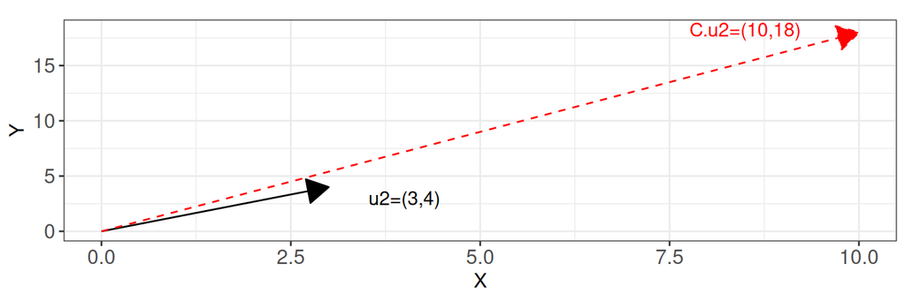

## Cálculo de autovalores

Los autovalores se calculan igualando a cero el determinante de la matriz \(A-\lambda I_n\) y hallando los valores de \(\lambda\) que anulan el determinante.

**Ejemplo:** \[\text{det}(C-\lambda\cdot I)=\begin{vmatrix} 6-\lambda & -2\\-2&6-\lambda \end{vmatrix}=(6-\lambda)^2-(-2)^2=\\36-12\lambda+\lambda^2-4=\lambda^2-12\lambda+32=0\Rightarrow\\ \lambda_1=4;\;\lambda_2=8 \]

## Cálculo de autovectores

Una vez calculados los autovalores de \(A\), los autovectores asociados se encuentran igualando la matriz \(A-\lambda I\) al vector \(\vec{0}\):

**Ejemplos:**

- \(\lambda_1=4 \Rightarrow \begin{pmatrix} 6-4& -2 &|& 0 \\-2&6-4&|&0 \end{pmatrix}\to \begin{pmatrix} 2& -2 &|& 0 \\-2&2&|&0 \end{pmatrix} \\\overset{F_2+F1}{\to} \begin{pmatrix} 2& -2 &|& 0 \\0&0&|&0 \end{pmatrix} \Rightarrow 2x-2y=0\Rightarrow x=y\) Dando un valor a \(x=1\), queda determinado \(y=1\), un autovector posible es \(\vec{v}_1=(1,1)\)

## Verificación:

\[\small C\cdot \vec{v}_1= \begin{pmatrix} 6-\lambda & -2\\-2&6-\lambda \end{pmatrix} \cdot \begin{pmatrix} 1\\1 \end{pmatrix}=\begin{pmatrix} 4\\4 \end{pmatrix}=4\cdot \begin{pmatrix} 1\\1 \end{pmatrix}=4\cdot\vec{v}_1\]

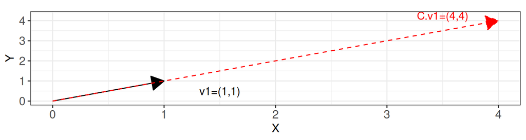

## Cálculo de autovectores

Una vez calculados los autovalores de \(A\), los autovectores asociados se encuentran igualando la matriz \(A-\lambda I\) al vector \(\vec{0}\):

**Ejemplos:**

- \(\lambda_2=8 \Rightarrow \begin{pmatrix} 6-8& -2 &|& 0 \\-2&6-8&|&0 \end{pmatrix}\to \begin{pmatrix} -2& -2 &|& 0 \\2&2&|&0 \end{pmatrix} \\\overset{F_2+F1}{\to} \begin{pmatrix} -2& -2 &|& 0 \\0&0&|&0 \end{pmatrix} \Rightarrow -2x-2y=0\Rightarrow x=-y\) Dando un valor a \(x=1\), queda determinado \(y=-1\), un autovector posible es \(\vec{v}_2=(1,-1)\)

## Verificación:

\[\small C\cdot \vec{v}_2= \begin{pmatrix} 6-\lambda & -2\\-2&6-\lambda \end{pmatrix} \cdot \begin{pmatrix} 1\\-1 \end{pmatrix}=\begin{pmatrix} 8\\-8 \end{pmatrix}=8\cdot \begin{pmatrix} 1\\-1 \end{pmatrix}=8\cdot\vec{v}_2\]

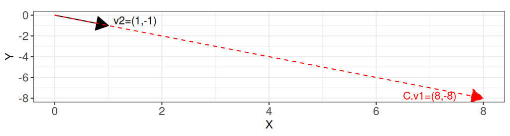

## Diagonalización

Si una matriz cuadrada \(A\in\mathbb{R}^{n \times n}\) tiene \(n\) autovectores linealmente independientes, se puede obtener lo siguiente: \[A=V\times D \times V^{-1}\] donde V se compone de los autovectores de \(A\) como columnas y la matriz \(D\) es una matriz diagonal con los autovalores en la diagonal.

**Ejemplo:** Teniendo \(\lambda_1=4\), \(\lambda_2=8\), \(\vec{v}_1=(1,1)\) y \(\vec{v}_2=(1,-1)\) para la matriz \(C\) \[\small V\times D \times V^{-1}=\begin{pmatrix} 1 & 1\\1&-1 \end{pmatrix} \times \begin{pmatrix} 4 & 0\\0&8 \end{pmatrix} \times \begin{pmatrix} \frac{1}{2} & \frac{1}{2}\\\frac{1}{2}&-\frac{1}{2} \end{pmatrix}=\\ \small \begin{pmatrix} 4 & 8\\4&-8 \end{pmatrix} \times \begin{pmatrix} \frac{1}{2} & \frac{1}{2}\\\frac{1}{2}&-\frac{1}{2} \end{pmatrix}=\begin{pmatrix} 6 & -2\\-2&6 \end{pmatrix}=C\]

## Ventajas de diagonalizar

Las potencias de una matriz \(A\) involucran muchos cálculos: \[\small A^{100}=A\times A\times \cdots \times A\]

```
## Unit: microseconds
##       expr  min   lq   mean median   uq   max neval
##  C %^% 100 1.84 1.86 3.1268   1.89 2.01 113.5   100
```

Si se expresa de forma diagonalizada, los cálculos son más simples, ya que la potencia de la matriz diagonal es la potencia de cada coordenada, y cada matriz con su inversa se va cancelando de forma que se obtiene: \[\small A^{100}=V\times D^{100} \times V^{-1}\]

```
## Unit: nanoseconds
##                 expr min  lq   mean median  uq   max neval
##  V %*% D100 %*% Vinv 629 640 829.27    651 671 14480   100
```

## Diagonalización ortonormal

**Cualquier** matriz simétrica \(A\in\mathbb{R}^{n \times n}\) tiene \(n\) autovectores linealmente independientes. Más aún, se pueden obtener de manera que \(V^{-1}=V^T\), es decir: \[A=V\times D \times V^{-1}=V\times D \times V^T\] donde V se compone de los autovectores de \(A\) como columnas y la matriz \(D\) es una matriz diagonal con los autovalores en la diagonal.

## **Ejemplo:**

Teniendo \(\lambda_1=4\), \(\lambda_2=8\), \(\vec{v}_1=(\frac{1}{\sqrt{2}},\frac{1}{\sqrt{2}})\) y \(\vec{v}_2=(\frac{1}{\sqrt{2}},-\frac{1}{\sqrt{2}})\) para la matriz \(C\) \[V\times D \times V^T=\begin{pmatrix} \frac{1}{\sqrt{2}} & \frac{1}{\sqrt{2}}\\\frac{1}{\sqrt{2}}&-\frac{1}{\sqrt{2}} \end{pmatrix} \times \begin{pmatrix} 4 & 0\\0&8 \end{pmatrix} \times \begin{pmatrix} \frac{1}{\sqrt{2}} & \frac{1}{\sqrt{2}}\\ \frac{1}{\sqrt{2}}&-\frac{1}{\sqrt{2}} \end{pmatrix}=\\ \begin{pmatrix} \frac{4}{\sqrt{2}} & \frac{8}{\sqrt{2}}\\-\frac{4}{\sqrt{2}}&-\frac{8}{\sqrt{2}} \end{pmatrix} \times \begin{pmatrix} \frac{1}{\sqrt{2}} & \frac{1}{\sqrt{2}}\\\frac{1}{\sqrt{2}} &-\frac{1}{\sqrt{2}} \end{pmatrix}=\begin{pmatrix} 6 & -2\\-2&6 \end{pmatrix}=C\]

## Ventajas de diagonalización ortonormal

La transpuesta es mucho menos costosa de calcular que una inversa:

```
## Unit: microseconds
##      expr  min    lq    mean median    uq   max neval
##  solve(V) 12.4 13.11 15.0208  13.53 14.24 93.55   100
```

```
## Unit: microseconds
##  expr  min  lq   mean median   uq    max neval
##  t(V) 2.39 2.5 7.1826  2.665 2.93 416.96   100
```

## Descomposición en valores singulares

Cuando una matriz \(A\) **NO es cuadrada**, se puede realizar una multiplicación similar, basadas en las matrices simétricas \(A\times A^T\) y \(A^T\times A\).

Los autovalores de \(A\times A^T\) y \(A^T\times A\) son iguales, salvo valores nulos que se agregan a la matriz más grande. Considerando \(U\) la matriz de autovectores ortonormales de \(A\times A^T\) y \(V\) la matriz de autovectores ortonormales de \(A^T\times A\), se obtiene: \[A=U\times D\times V^T\] en este caso, la matriz \(D\) será rectangular, pero en la diagonal que le corresponde se encuentran la raíz cuadrada de los autovalores en común entre ambas matrices simétricas.

## Ejemplo

\[A=\begin{pmatrix} 2& -1 &1\\-2&-1&1 \end{pmatrix}\Rightarrow A^T=\begin{pmatrix} 2& -2 \\-1&-1 \\1&1 \end{pmatrix}\]

## Ejemplo

\[A=\begin{pmatrix} 2& -1 &1\\-2&-1&1 \end{pmatrix}\Rightarrow A^T=\begin{pmatrix} 2& -2 \\-1&-1 \\1&1 \end{pmatrix}\]

\[A\times A^T=\begin{pmatrix} 6&-2\\-2&6 \end{pmatrix};\\\text{Autovalores:}\;\lambda_1=4,\lambda_2=8;\\ \text{Autovectores:}\;\vec{v}_1=\left(\frac{1}{\sqrt{2}},\frac{1}{\sqrt{2}}\right),\vec{v}_2=\left(\frac{1}{\sqrt{2}},-\frac{1}{\sqrt{2}}\right)\]

## Ejemplo

\[A^T\times A=\begin{pmatrix} 8&0 & 0\\0&2&-2\\0&-2&2 \end{pmatrix};\\ \text{Autovalores:}\;\lambda_1=4,\lambda_2=8,\lambda_3=0;\\\text{Autovectores:}\;\vec{v}_1=\left(0,-\frac{1}{\sqrt{2}},\frac{1}{\sqrt{2}}\right),\vec{v}_2=\left(1,0,0\right),\\\vec{v}_3=\left(0,\frac{1}{\sqrt{2}},\frac{1}{\sqrt{2}}\right)\]

## Ejemplo

\[\small A=\begin{pmatrix} 2& -1 &1\\-2&-1&1 \end{pmatrix}\Rightarrow A^T=\begin{pmatrix} 2& -2 \\-1&-1 \\1&1 \end{pmatrix}\] \[\small U\times D\times V^T=\\ \small \begin{pmatrix} \frac{1}{\sqrt{2}}&\frac{1}{\sqrt{2}}\\\frac{1}{\sqrt{2}}&-\frac{1}{\sqrt{2}} \end{pmatrix}\times \begin{pmatrix} \sqrt{4}&0 & 0\\0&\sqrt{8}&0 \end{pmatrix}\times \begin{pmatrix} 0&1 & 0\\ -\frac{1}{\sqrt{2}}&0&\frac{1}{\sqrt{2}} \\ \frac{1}{\sqrt{2}}&0&\frac{1}{\sqrt{2}} \end{pmatrix}^T=\\\small \begin{pmatrix} \sqrt{2}&2 & 0\\\sqrt{2}&-2&0 \end{pmatrix} \times \begin{pmatrix} 0&-\frac{1}{\sqrt{2}} & \frac{1}{\sqrt{2}}\\1 &0&0 \\ 0&\frac{1}{\sqrt{2}}&\frac{1}{\sqrt{2}} \end{pmatrix}=\]

\[\small =\begin{pmatrix} 2& -1 &1\\-2&-1&1 \end{pmatrix}=A\]